# Lab 6

Author

Filippo Gambarota

```r
devtools::load_all()
library(tidyverse)
library(ggeffects)
```

# EDA

## Loading data

```r
data("psych")
dat <- psych
```

Given that we did not introduced random-effects models, we select a single subject to analyze.

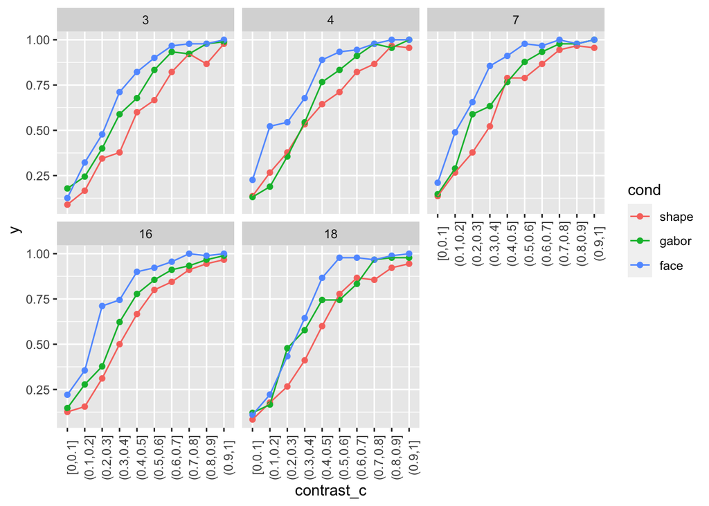

```r
cc <- seq(0, 1, 0.1)

dat$contrast_c <- cut(dat$contrast, cc, include.lowest = TRUE)

dat |>
  filter(id %in% sample(unique(dat$id), 5)) |>
  group_by(id, cond, contrast_c) |>
  summarise(y = mean(y)) |>
  ggplot(aes(x = contrast_c, y = y, color = cond, group = cond)) +
  geom_point() +
  geom_line() +
  theme(axis.text.x = element_text(angle = 90)) +
  facet_wrap(~id)
```

```r
dat <- filter(dat, id == 6)
```

We have several interesting stuff to estimate. Let’s start by fitting a simple model:

```r
fit1 <- glm(y ~ contrast, data = dat, family = binomial(link = "logit"))
summary(fit1)
```

```
Call:
glm(formula = y ~ contrast, family = binomial(link = "logit"),
    data = dat)

Deviance Residuals:
    Min       1Q   Median       3Q      Max
-2.8826  -0.6003   0.2343   0.5974   2.1113

Coefficients:
            Estimate Std. Error z value Pr(>|z|)
(Intercept) -2.11482    0.09237  -22.90   <2e-16 ***
contrast     6.41786    0.22165   28.95   <2e-16 ***
---
Signif. codes:  0 '***' 0.001 '**' 0.01 '*' 0.05 '.' 0.1 ' ' 1

(Dispersion parameter for binomial family taken to be 1)

    Null deviance: 4038.1  on 2999  degrees of freedom
Residual deviance: 2500.5  on 2998  degrees of freedom
AIC: 2504.5

Number of Fisher Scoring iterations: 5
```

The parameters `(Intercept)` and `contrast` are respectively the probability of saying yes for stimuli with 0 contrast. Seems odd but in Psychophysics this is a very interesting information. We can call it the false alarm rate. We usually expect this rate to be low, ideally 0.

```r
plogis(coef(fit1)[1])
```

```
(Intercept)
   0.107665
```

The `contrast` is the slope i.e. the increase in the log odds of saying yes for a unit increase in `contrast`. In this case this parameter is hard to intepret, let’s change the scale of the contrast:

```r
dat$contrast10 <- dat$contrast * 10
fit1 <- glm(y ~ contrast10, data = dat, family = binomial(link = "logit"))
summary(fit1)
```

```
Call:
glm(formula = y ~ contrast10, family = binomial(link = "logit"),
    data = dat)

Deviance Residuals:
    Min       1Q   Median       3Q      Max
-2.8826  -0.6003   0.2343   0.5974   2.1113

Coefficients:
            Estimate Std. Error z value Pr(>|z|)
(Intercept) -2.11482    0.09237  -22.90   <2e-16 ***
contrast10   0.64179    0.02217   28.95   <2e-16 ***
---
Signif. codes:  0 '***' 0.001 '**' 0.01 '*' 0.05 '.' 0.1 ' ' 1

(Dispersion parameter for binomial family taken to be 1)

    Null deviance: 4038.1  on 2999  degrees of freedom
Residual deviance: 2500.5  on 2998  degrees of freedom
AIC: 2504.5

Number of Fisher Scoring iterations: 5
```

Now the `contrast10` is the increase in the log odds of saying yes for an increase of 10% contrast. Using the divide-by-4 rule we obtain an maximal increase of 0.1604465 of probability of saying yes.

Another interesting parameter is the threshold. In psychophysics the threshold is the required $x$ level (in this case `contrast`) to obtain a certain proportions of $y$ response.

For a logistic distribution (see Knoblauch and Maloney 2012) the 50% threshold can be estimated as $-\frac{\beta_0}{\beta_1}$ thus:

```r
-(coef(fit1)[1]/coef(fit1)[2])
```

```
(Intercept)
   3.295206
```

Then the slope is simply the inverse of the regression slope and represent the increase in performance/visibility for a unit increase in $x$:

```r
1/coef(fit1)[2]
```

```
contrast10
  1.558152
```

In fact, we can use these parameters to plot a logistic distribution:

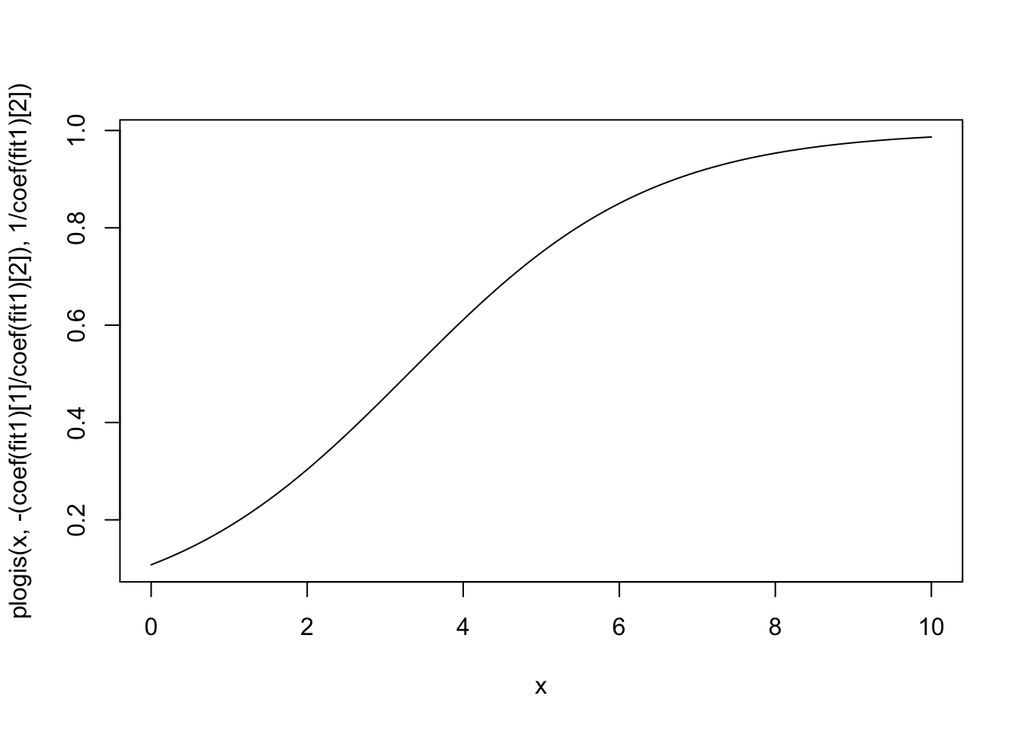

```r
curve(plogis(x, -(coef(fit1)[1]/coef(fit1)[2]), 1/coef(fit1)[2]),
      0, 10)
```

That is very similar to the effects estimated by our model:

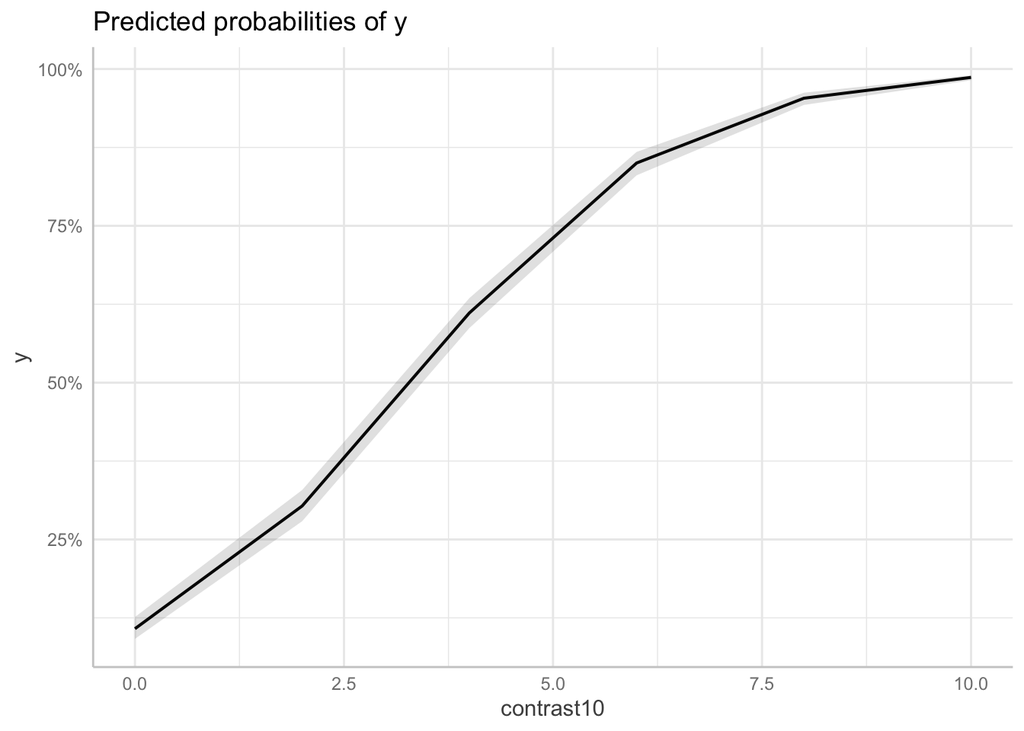

```r
plot(ggeffect(fit1))
```

## References

Knoblauch, Kenneth, and Laurence T Maloney. 2012. *Modeling Psychophysical Data in r*. New York, NY: Springer New York. https://doi.org/10.1007/978-1-4614-4475-6.